# Examen Final

Análisis Estadístico de Datos en Salud

PFC 2023 -– IETSI, EsSalud

Autor/a

Percy Soto-Becerra

Fecha de publicación

21-06-2023

## 1 Introducción

Para este Examen Final, procesaremos los datos del artículo titulado **“Comorbid Depression and Heart Failure: A Community Cohort Study”** y publicado en la revista Plos One (doi: https://journals.plos.org/plosone/article?id=10.1371/journal.pone.0158570).

Hemos modificado ligeramente los datos originales para agregarles algunos problemas que permitan enfrentar problemas de calidad de datos.

En este examen nos centraremos solo en manejo de datos y análisis incicial de datos incluyendo gráficos y tablas reproducibles. Todos los ejercicios requieren que usted haga algún tipo de comentario personal, ya sea describir los resultados observados o comentar el proceso / razonamiento seguido.

**Advertencia**

Es importante que se respondan con comentarios, no solo código! La pregunta que no tiene comentarios solo valdrá 25% del puntaje total.

## 2 Entregable

Deberá enviar al siguiente correo electrónico una carpeta comprimida o compartida por Drive / Onedrive /Dropbox con los siguientes archivos:

**Importante**

- **Problem_Set1_ApellidoPaterno_ApellidoMaterno_Nombre.Rproj** (configure el proyecto como aprendimos al inicio)
- **Problem_Set1_ApellidoPaterno_ApellidoMaterno_Nombre.qmd**
- **Problem_Set1_ApellidoPaterno_ApellidoMaterno_Nombre.html** (resultado de renderizar)

La carpeta comprimida o compartida por nube (Drive/Onedrive/Dropbox) deberá llamarse según las especificaciones siguientes:

**Importante**

**Problem_Set1_ApellidoPaterno_Nombre**.

Ejemplo:

**Problem_Set1_SotoBecerra_Percy**

**Advertencia**

Se descontará 1 punto por no seguir las instrucciones de nombrado de carpeta.

## 3 Ejercicios

### 3.1 Ejercicio 1: Cargue los paquetes que usará. Comentar con # al lado de cada paquete un resumen breve de para qué lo usarán. **Tip: Use library()**

*Nota: Todos los paquetes que usará deberán estar en este chunk, no en otro chunk posterior*

```r
library(tidyverse)     # Varias funciones de tidyverse (dplyr, ggplot2, etc.)
library(rio)           # Navaja suiza de la importación de datos
library(janitor)       # Funciones para manejo y limpieza de datos (p. ej, get_dupes)
library(labelled)      # Funciones para manipular etiquetas: set_variable_labels()
library(skimr)         # Análisis inicial de datos
library(gtsummary)     # Tablas reproducibles
library(Hmisc)         # Funciones para inspeccionar datos
```

### 3.2 Ejercicio 2: Importe los datos denominados `"pone.0158570.s002_modified.xlsx"`Descargue aquí

```r
# Escriba aquí el código
```

### 3.3 Ejercicio 3: Haga un inspección global de los datos

- **Dé un vistazo a los datos. Describa brevemente sus resultados.**

```r
# Escriba aquí el código
```

- **Obtenga un resumen global superficial de los datos. Describa brevemente sus resultados.**

```r
# Escriba aquí el código
```

- **Obtenga una descripción un poco más detallada variable por variable de los datos. Describa brevementesus resultados.**

```r
# Escriba aquí el código
```

### 3.4 Ejercicio 4: Procese los datos según el siguiente diccionario:

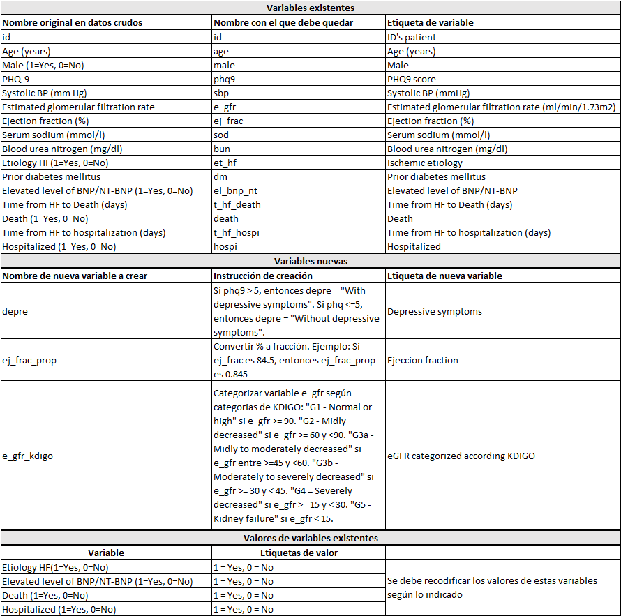

- En un solo pipeline, haga lo siguiente:
  - 1. Renombre variables.
  - 2. Recodifique las etiquetas de las variables categóricas.
  - 3. Cree las nuevas variables.
  - 4. Etiquete a las variables.

```r
# Escriba aquí el código
```

### 3.5 Ejercicio 5: Identifique duplicados

- **Identifique duplicados de fila. Describa brevementesus resultados.**

```r
# Escriba aquí el código
```

- **Identifique duplicados de id. Describa brevemente sus resultados.**

```r
# Escriba aquí el código
```

- **Solo si hubo duplicados de fila, elimine los duplicados de fila, quedándose solo con una versión de cada observación. Comente el proceso/razonamiento.**

*Tip: Puedes usar distinct()*

```r
# Escriba aquí el código
```

- **Solo si hubo duplicados de id, elimine el duplicado de fila que menos información completa tenga. Comente el proceso/razonamiento.**

*Tip: Puedes usar slice() o filter()*

```r
# Escriba aquí el código
```

### 3.6 Ejercicio 6: Identifique datos perdidos

- **Presente el número de datos perdidos y tasa de completitud variable por variable en una sola salida. Describa los resultados relacionados a datos perdidos.**

```r
# Escriba aquí el código
```

- **Muestre gráficos de datos perdidos y como se agrupan entre variables.Describa los resultados relacionados a datos perdidos.**

```r
# Escriba aquí el código
```

### 3.7 Ejercicio 7: Haga las siguientes consultas (“queries”) con los datos limpios (renombrados, etiquetados y sin duplicados)

- **Seleccione las variables id, age y phq-9. Muestre los participantes que tienen edades entre 50 y 55 años**

```r
# Escriba aquí el código
```

- **Seleccione las variables id, ej_Frac, sod, bun y et_hf. Luego, muestre a los participantes que tiene etiología isquémica.**

```r
# Escriba aquí el código
```

- **¿Quiénes fueron los pacientes mujeres que sobrevivieron y tuvieron un phq-9 > 10?**

```r
# Escriba aquí el código
```

- **¿Cuáles fueron los valores de tiempo a muerte en los pacientes varones que murieron, que tuvieron etiología isquémica y un puntaj de phq-9 > 10?**

```r
# Escriba aquí el código
```

### 3.8 Ejercicio 8: Haga los siguientes gráficos:

- **Mediante un gráfico de cajas, compare los valores de ejection fraction (%) entre los pacientes con etiología isquémica versus sin etiología isquémica. Muestre el resultado más simple posible.**

```r
# Escriba aquí el código
```

- **Mediante un gráfico de cajas, compare los valores de ejection fraction (%) entre los pacientes con etiología isquémica versus sin etiología isquémica. Muestre el resultado más elaborado posible: Elija un tema de su agrado, agregue etiquetas (título general, título de eje X, título de eje Y, etiquetas de leyenda si aplica), modifique la escala de colores, etc.**

```r
# Escriba aquí el código
```

- **Use un gráfico de cajas y puntos dispersos (combinelos), para mostrar el nivel de bun según sexo. Muestre el resultado más simple posible.**

*Tip: use geom_jitter() para los puntos dispersos. Más info aquí: https://ggplot2.tidyverse.org/reference/geom_jitter.html*

```r
# Escriba aquí el código
```

- **Use un gráfico de cajas y puntos (combinelos), para mostrar el nivel de bun según sexo. Muestre el resultado más elaborado posible: Elija un tema de su agrado, agregue etiquetas (título general, título de eje X, título de eje Y, etiquetas de leyenda si aplica), modifique la escala de colores, etc.**

*Tip: use geom_jitter() para los puntos dispersos. Más info aquí: https://ggplot2.tidyverse.org/reference/geom_jitter.html*

```r
# Escriba aquí el código
```

### 3.9 Ejercicio 9: Exporte los datos a los siguientes formatos:

- Formato de R: “.rds”

```r
# Escriba aquí el código
```

- Formato de Excel: “.xlsx”

```r
# Escriba aquí el código
```

- Formato de archivo plano: “.csv”

```r
# Escriba aquí el código
```

- Formato de Stata: “.dta”

```r
# Escriba aquí el código
```

### 3.10 Ejercicio 10: Renderice el archivo .qmd final. Comparta la carpeta entera, la cual debe contener el .qmd, así como el .html.